# EDA - In Detail

Let us go through real dataset-based examples in Python for handling outliers, checking for null values, balancing data, and other exploratory data analysis (EDA) checks commonly performed in the data science project's initial phase.

## Handling Outliers

- Identifying outliers using box plots and other methods.
- Strategies for handling outliers: removal, transformation, or binning.
- Python code for outlier handling.

## Checking for Null Values

- Understanding the importance of handling missing data.
- Methods to check for null values in the dataset.
- Techniques to handle null values: imputation or removal.
- 9Python code for null value check and imputation.

## Balancing Data

- Recognizing class imbalance in classification problems.
- Techniques for balancing imbalanced datasets: oversampling and undersampling.
- Python code for data balancing.

## Handling Categorical Variables

- Strategies for converting categorical data to numerical format.
- Techniques: label encoding and one-hot encoding.
- Python code for categorical variable handling.

# 1. Outliers

## Identifying Outliers using Box Plots and Other Methods:

Outliers are data points that significantly deviate from the rest of the data. They can have a substantial impact on statistical analyses and machine learning models, potentially leading to biased results. One common approach to identify outliers is by using box plots.

A box plot, also known as a box-and-whisker plot, provides a graphical representation of the data's distribution and identifies potential outliers. In a box plot, the "box" represents the interquartile range (IQR), which contains the middle 50% of the data. The "whiskers" extend to the minimum and maximum values within a certain distance from the upper and lower quartiles. Data points outside the whiskers are considered potential outliers.

Apart from box plots, other methods for identifying outliers include statistical techniques such as the z-score method, the modified z-score method, and the Tukey method.

## Strategies for Handling Outliers: Removal, Transformation, or Binning:

Once we have identified the outliers, we can apply various strategies to handle them. The choice of strategy depends on the nature of the data and the specific requirements of the analysis.

Removal: The simplest approach is to remove the outliers from the dataset. However, this should be done with caution, as removing too many outliers can lead to a loss of important information and potentially bias the analysis.

Transformation: In some cases, it may be appropriate to transform the data to reduce the impact of outliers. Common transformations include taking the logarithm, square root, or reciprocal of the data.

Binning: Binning involves grouping the data into bins or categories. Outliers can be placed into a separate bin, allowing us to analyze their impact separately.

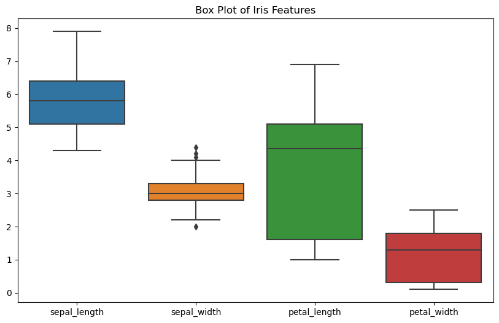

```
Original DataFrame Shape: (150, 5)
DataFrame with Outliers Removed Shape: (149, 5)
```

```python
import pandas as pd
import seaborn as sns
import matplotlib.pyplot as plt

# Load the Iris dataset
url = "https://archive.ics.uci.edu/ml/machine-learning-databases/iris/iris.data"
columns = ['sepal_length', 'sepal_width', 'petal_length', 'petal_width', 'species']
df = pd.read_csv(url, names=columns)

# Identifying Outliers using Box Plots
plt.figure(figsize=(10, 6))
sns.boxplot(data=df[['sepal_length', 'sepal_width', 'petal_length', 'petal_width']])
plt.title('Box Plot of Iris Features')
plt.show()

# Handling Outliers - Removal Strategy
# Using z-score to identify and remove outliers in 'sepal_width'
from scipy.stats import zscore

z_scores = zscore(df['sepal_width'])
outlier_indices = (z_scores > 3) | (z_scores < -3)

# Removing outliers
df_no_outliers = df[~outlier_indices]

# Compare the original and cleaned dataframes
print("Original DataFrame Shape:", df.shape)
print("DataFrame with Outliers Removed Shape:", df_no_outliers.shape)
```

# 2. Missing Data

## Understanding the Importance of Handling Missing Data:

Missing data is a common issue in real-world datasets. It can occur due to various reasons, such as data entry errors, sensor malfunctions, or survey non-responses. Handling missing data is essential because it can significantly impact the accuracy and reliability of data analysis and machine learning models. Ignoring missing data or handling it improperly may lead to biased results and erroneous conclusions.

## Methods to Check for Null Values in the Dataset:

Before proceeding with handling missing data, it's crucial to identify which columns contain null values. There are several methods to check for null values in the dataset:

- Using the isnull() method: The isnull() method returns a boolean DataFrame where each element is True if the value is missing (i.e., null) and False otherwise.
- Using the info() method: The info() method provides a concise summary of the DataFrame, including the count of non-null values in each column.
- Using the isna() method: Similar to isnull(), the isna() method also returns a boolean DataFrame, but it is an alias for isnull().

## Techniques to Handle Null Values: Imputation or Removal:

Once we identify the columns with missing values, we can decide how to handle them. The two common techniques are:

### Imputation:

Imputation involves replacing missing values with estimated or calculated values. Popular imputation methods include mean, median, mode, or predictive models.

### Removal:

Removing rows or columns with missing values is another option. However, this should be done with caution, as it may result in significant data loss.

Let's use the Iris dataset to demonstrate how to check for null values and handle them using the "imputation" technique.

```python
import pandas as pd

# Load the Iris dataset with some missing values
url = "https://archive.ics.uci.edu/ml/machine-learning-databases/iris/iris.data"
columns = ['sepal_length', 'sepal_width', 'petal_length', 'petal_width', 'species']
df = pd.read_csv(url, names=columns)

# Introduce some missing values in 'sepal_width' column
import numpy as np
mask = np.random.choice([True, False], size=df.shape[0], p=[0.1, 0.9])
df.loc[mask, 'sepal_width'] = np.nan

# Checking for Null Values
# Method 1: Using isnull()
print(df.isnull().sum())

# Method 2: Using info()
print(df.info())

# Method 3: Using isna() (alias for isnull())
print(df.isna().sum())

# Handling Null Values - Imputation Strategy
# Impute the missing values in 'sepal_width' with the mean of the column
df_imputed = df.copy()
mean_sepal_width = df['sepal_width'].mean()
df_imputed['sepal_width'].fillna(mean_sepal_width, inplace=True)

# Compare the original and imputed dataframes
print("Original DataFrame:")
print(df.head())

print("\nDataFrame with Imputed Values:")
print(df_imputed.head())
print(df_imputed.isnull().sum())
```

```
sepal_length     0
sepal_width     11
petal_length     0
petal_width      0
species          0
dtype: int64
<class 'pandas.core.frame.DataFrame'>
RangeIndex: 150 entries, 0 to 149
Data columns (total 5 columns):
 #   Column        Non-Null Count  Dtype
---  ------        --------------  -----
 0   sepal_length  150 non-null    float64
 1   sepal_width   139 non-null    float64
 2   petal_length  150 non-null    float64
 3   petal_width   150 non-null    float64
 4   species       150 non-null    object
dtypes: float64(4), object(1)
memory usage: 6.0+ KB
None
sepal_length     0
sepal_width     11
petal_length     0
petal_width      0
species          0
dtype: int64
Original DataFrame:
   sepal_length  sepal_width  petal_length  petal_width      species
0           5.1          NaN           1.4          0.2  Iris-setosa
1           4.9          3.0           1.4          0.2  Iris-setosa
2           4.7          3.2           1.3          0.2  Iris-setosa
3           4.6          3.1           1.5          0.2  Iris-setosa
4           5.0          3.6           1.4          0.2  Iris-setosa

DataFrame with Imputed Values:
   sepal_length  sepal_width  petal_length  petal_width      species
0           5.1     3.039568           1.4          0.2  Iris-setosa
1           4.9     3.000000           1.4          0.2  Iris-setosa
2           4.7     3.200000           1.3          0.2  Iris-setosa
3           4.6     3.100000           1.5          0.2  Iris-setosa
4           5.0     3.600000           1.4          0.2  Iris-setosa
sepal_length    0
sepal_width     0
petal_length    0
petal_width     0
species         0
dtype: int64
```

# 3. Recognizing Class Imbalance in Classification Problems:

Class imbalance occurs when the distribution of classes in the target variable is significantly skewed, with one or more classes having a much smaller number of samples compared to the majority class. This is common in real-world datasets, such as fraud detection, disease diagnosis, or rare event prediction. Class imbalance can lead to biased model training, where the classifier may prioritize the majority class and perform poorly on the minority class.

## Techniques for Balancing Imbalanced Datasets: Oversampling and Undersampling:

To address class imbalance, we can use two main techniques: oversampling and undersampling.

### Oversampling:

Oversampling involves increasing the number of samples in the minority class by replicating existing samples or generating synthetic samples. This technique aims to balance the class distribution by providing more training examples for the minority class.

### Undersampling:

Undersampling involves reducing the number of samples in the majority class by randomly selecting a subset of samples. This technique aims to balance the class distribution by reducing the dominance of the majority class.

```python
import pandas as pd
from sklearn.datasets import load_iris
from sklearn.utils import resample

# Load the Iris dataset
data = load_iris()
df = pd.DataFrame(data.data, columns=data.feature_names)
df['species'] = data.target_names[data.target]

# Introduce class imbalance by removing some samples from the majority class (versicolor)
df_imbalanced = df[df['species'] != 'versicolor']

# Count the number of samples for each class in the imbalanced dataset
print(df_imbalanced['species'].value_counts())

# Balancing the dataset - Oversampling and Undersampling

# Oversampling the minority class (virginica)
virginica = df_imbalanced[df_imbalanced['species'] == 'virginica']
versicolor = df_imbalanced[df_imbalanced['species'] == 'versicolor']

# Upsample the minority class to match the number of samples in the majority class (setosa)
virginica_upsampled = resample(virginica, replace=True, n_samples=len(versicolor))

# Combine the upsampled minority class with the majority class
df_balanced_oversampled = pd.concat([versicolor, virginica_upsampled])

# Count the number of samples for each class in the balanced dataset (oversampled)
print(df_balanced_oversampled['species'].value_counts())

# Undersampling the majority class (setosa)
setosa = df_imbalanced[df_imbalanced['species'] == 'setosa']
setosa_downsampled = resample(setosa, replace=False, n_samples=len(virginica))

# Combine the downsampled majority class with the minority class
df_balanced_undersampled = pd.concat([virginica, setosa_downsampled])

# Count the number of samples for each class in the balanced dataset (undersampled)
print(df_balanced_undersampled['species'].value_counts())
```

```
setosa       50
virginica    50
Name: species, dtype: int64
Series([], Name: species, dtype: int64)
virginica    50
setosa       50
Name: species, dtype: int64
```

Remember, the choice between oversampling and undersampling depends on the specific dataset and the goals of the analysis. Oversampling increases the number of minority samples, while undersampling reduces the number of majority samples. Both techniques can help improve the performance of classifiers in imbalanced classification tasks. However, for certain datasets, other advanced techniques such as

### SMOTE (Synthetic Minority Over-sampling Technique) or

### ADASYN (Adaptive Synthetic Sampling)

may be more effective in generating synthetic samples for the minority class. Always evaluate the performance of the model on a separate validation set to ensure that the data balancing technique does not introduce overfitting or other biases.

# 4. Encoding Categorical Values to Numeric Values

## Why and When to Change Categorical Values to Numeric Values:

Most machine learning algorithms and statistical models require numerical input data. Therefore, categorical variables, which represent qualitative attributes with discrete categories, need to be converted into numerical format. Here's why and when we should change categorical values to numeric values:

### Algorithm Compatibility:

Many machine learning algorithms, such as regression, support vector machines, and neural networks, can only work with numeric inputs. Converting categorical variables to numeric form enables us to use a wider range of algorithms.

### Model Interpretability:

Some models, like decision trees, can handle categorical variables directly. However, encoding them into numeric values can help with model interpretability and make it easier to understand the model's decision-making process.

### Encoding Ordinal Variables:

Ordinal variables have a meaningful order, and converting them to numeric values can preserve this order, which is essential for certain models and analyses.

### Encoding Nominal Variables:

Nominal variables have no inherent order, so we need to use specific techniques (e.g., one-hot encoding) to represent them numerically without introducing any unintended ordinal relationships.

## Strategies for Converting Categorical Data to Numerical Format:

There are several strategies for converting categorical data to numerical format:

### Label Encoding:

Label encoding assigns a unique integer to each category of the categorical variable. It works well for ordinal variables with an inherent order but may introduce ordinal relationships in nominal variables, leading to incorrect interpretations by the model.

### One-Hot Encoding:

One-hot encoding creates binary columns for each category of the categorical variable. Each binary column represents the presence (1) or absence (0) of a particular category. One-hot encoding is suitable for nominal variables to prevent introducing ordinal relationships.

```python
import pandas as pd
from sklearn.preprocessing import LabelEncoder, OneHotEncoder

# Load the Titanic dataset
url = "https://raw.githubusercontent.com/datasciencedojo/datasets/master/titanic.csv"
df = pd.read_csv(url)

# Select some columns with categorical variables
selected_columns = ['Pclass', 'Sex', 'Embarked']

# Original DataFrame with categorical variables
print("Original DataFrame:")
print(df[selected_columns].head())

# Label Encoding
label_encoder = LabelEncoder()
for col in selected_columns:
    df[col + '_label'] = label_encoder.fit_transform(df[col])

# Transformed DataFrame using Label Encoding
print("\nDataFrame after Label Encoding:")
print(df[[col + '_label' for col in selected_columns]].head())

# One-Hot Encoding
one_hot_encoder = OneHotEncoder(drop='first', sparse=False)
one_hot_encoded = one_hot_encoder.fit_transform(df[selected_columns])

# Transformed DataFrame using One-Hot Encoding
column_names = one_hot_encoder.get_feature_names_out(selected_columns)
df_one_hot_encoded = pd.DataFrame(one_hot_encoded, columns=column_names)
print("\nDataFrame after One-Hot Encoding:")
print(df_one_hot_encoded.head())
```

```
Original DataFrame:
   Pclass     Sex Embarked
0       3    male        S
1       1  female        C
2       3  female        S
3       1  female        S
4       3    male        S

DataFrame after Label Encoding:
   Pclass_label  Sex_label  Embarked_label
0             2          1               2
1             0          0               0
2             2          0               2
3             0          0               2
4             2          1               2

DataFrame after One-Hot Encoding:
   Pclass_2  Pclass_3  Sex_male  Embarked_Q  Embarked_S  Embarked_nan
0       0.0       1.0       1.0         0.0         1.0           0.0
1       0.0       0.0       0.0         0.0         0.0           0.0
2       0.0       1.0       0.0         0.0         1.0           0.0
3       0.0       0.0       0.0         0.0         1.0           0.0
4       0.0       1.0       1.0         0.0         1.0           0.0
```

The choice between label encoding and one-hot encoding depends on the nature of the categorical variables and the requirements of the model. For ordinal variables, label encoding can be more appropriate, while for nominal variables, one-hot encoding is generally preferred to avoid introducing any unintended relationships. Always ensure to handle categorical variables properly to avoid any potential biases or misinterpretations in the model.